# Diet Distribution Analysis

Can food trigger people’s emotional and mental health? Absolutely. Many people are surprised that there is a close link between mental health disorders and nutritional deficiencies. The role of food is more prominent than people think! Bad eating and drinking habits can negatively impact people’s thoughts and behaviors. Malnutrition can also lead to physical health problems, affecting people’s feelings and way of thinking. Few people understand the close relationship between nutrition and mental health disorders such as depression and anxiety. Depression and anxiety are often regarded as mysterious diseases shrouded in shame. Depression is generally believed to be based on chemical imbalances or unstable emotions. However, surprisingly, nutrition often plays a significant role in the onset, duration, and intensity of depression. With that being said, the diet distribution analysis portion will compare and contrast the relationship between healthy diet patterns and mental health by observing obesity and a healthy diet.

Top Five Countries with the Highest Obesity Percentage

| Country | Obesity | Rank |
| --- | --- | --- |
| Kiribati | 45.6% | 1 |
| Samoa | 45.5% | 2 |
| United States of America | 37.3% | 3 |
| Kuwait | 37% | 4 |
| Saudi Arabia | 35% | 5 |

##### The Recommended Simple Daily Diet Intake by The USDA Center for Nutrition Policy and Promotion

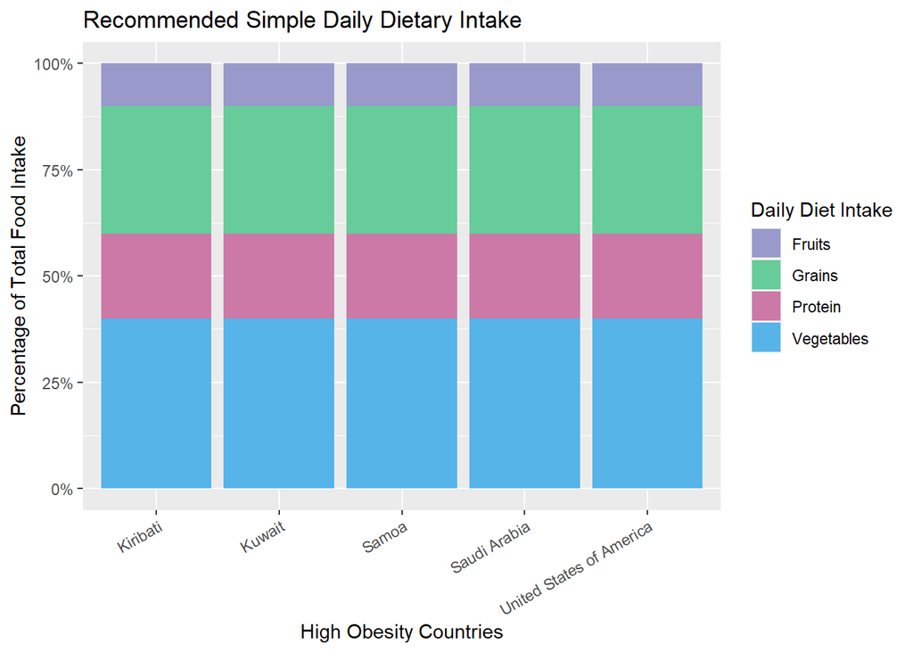

Based on the data obtained from the Food and Agriculture Organization of the United Nations, the top five countries with the highest obesity rate are listed in the table (left). The plot on the right is a simple daily diet guideline recommended by USDA Center for Nutrition Policy and Promotion: 30% grains, 40% vegetables, 10% fruits, and 20% protein. Below, look at different categories of food intake in five obese countries: food supply quantity (kg), fat quantity, energy intake (kcal), and protein, to predict the relationship between healthy eating patterns, obesity rates, and mental health.